# Analyse

Dorsa Aghajani

```r
library(TitanicPackage)
library(carData)

data("TitanicSurvival")
titanic <- TitanicSurvival
```

## R Markdown

```r
library(carData)    # pour TitanicSurvival
library(dplyr)      # pour la manipulation de données
library(ggplot2)    # pour les graphiques
```

#Chargement des données

```r
data("TitanicSurvival")
titanic <- TitanicSurvival
head(titanic)
```

```
##                                 survived    sex     age passengerClass
## Allen, Miss. Elisabeth Walton        yes female 29.0000            1st
## Allison, Master. Hudson Trevor       yes   male  0.9167            1st
## Allison, Miss. Helen Loraine          no female  2.0000            1st
## Allison, Mr. Hudson Joshua Crei       no   male 30.0000            1st
## Allison, Mrs. Hudson J C (Bessi       no female 25.0000            1st
## Anderson, Mr. Harry                  yes   male 48.0000            1st
```

Le jeu de données TitanicSurvival contient des informations sur les passagers du Titanic : âge, sexe, classe du billet et statut de survie.

#Présentation des données Les variables principales sont : survived (survie), sex, passengerClass et age.

```r
str(titanic)
```

```
## 'data.frame':    1309 obs. of  4 variables:
##  $ survived      : Factor w/ 2 levels "no","yes": 2 2 1 1 1 2 2 1 2 1 ...
##  $ sex           : Factor w/ 2 levels "female","male": 1 2 1 2 1 2 1 2 1 2 ...
##  $ age           : num  29 0.917 2 30 25 ...
##  $ passengerClass: Factor w/ 3 levels "1st","2nd","3rd": 1 1 1 1 1 1 1 1 1 1 ...
```

```r
summary(titanic)
```

```
##  survived      sex           age          passengerClass
##  no :809   female:466   Min.   : 0.1667   1st:323
##  yes:500   male  :843   1st Qu.:21.0000   2nd:277
##                         Median :28.0000   3rd:709
##                         Mean   :29.8811
##                         3rd Qu.:39.0000
##                         Max.   :80.0000
##                         NA's   :263
```

#Statistiques descriptives détaillées

```r
titanic_clean <- titanic %>%
filter(!is.na(age))
summary(titanic_clean$age)
```

```
##    Min. 1st Qu.  Median    Mean 3rd Qu.    Max.
##  0.1667 21.0000 28.0000 29.8811 39.0000 80.0000
```

Répartition des passagers par sexe et par classe :

```r
table(titanic$sex)
```

```
##
## female   male
##    466    843
```

```r
table(titanic$passengerClass)
```

```
##
## 1st 2nd 3rd
## 323 277 709
```

```r
table(titanic$survived)
```

```
##
##  no yes
## 809 500
```

La majorité des passagers sont des hommes et des passagers de 3ᵉ classe. La proportion de survivants est inférieure à celle des non-survivants.

#Visualisation de la survie Survie selon le sexe:

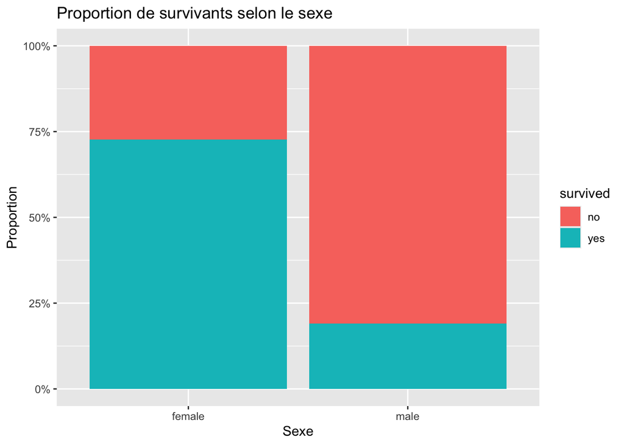

```r
ggplot(titanic, aes(x = sex, fill = survived)) +
geom_bar(position = "fill") +
labs(x = "Sexe", y = "Proportion",
title = "Proportion de survivants selon le sexe") +
scale_y_continuous(labels = scales::percent)
```

Les femmes survivent beaucoup plus souvent que les hommes, ce qui correspond aux priorités d’évacuation. Survie selon la classe:

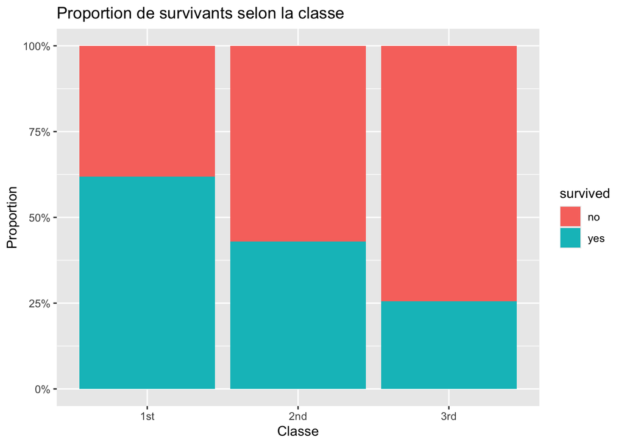

```r
ggplot(titanic, aes(x = passengerClass, fill = survived)) +
geom_bar(position = "fill") +
labs(x = "Classe", y = "Proportion",
title = "Proportion de survivants selon la classe") +
scale_y_continuous(labels = scales::percent)
```

Les passagers de 1ʳᵉ classe ont nettement plus de chances de survie, tandis que ceux de 3ᵉ classe sont les plus touchés.

#Âge en fonction du statut de survie

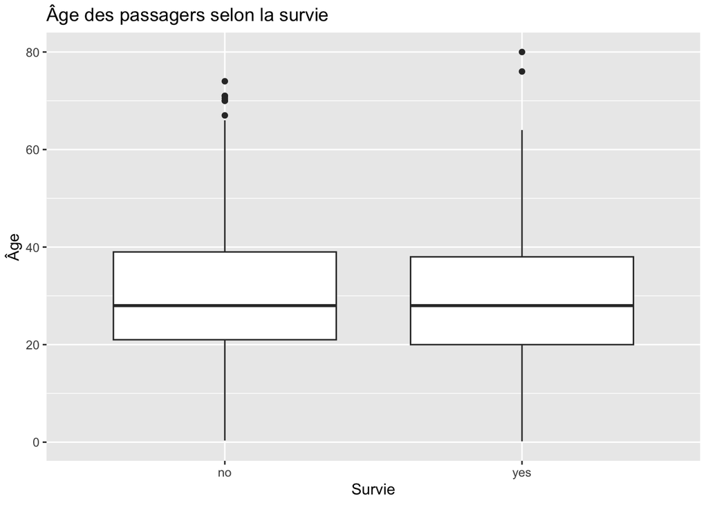

```r
titanic_clean <- titanic[!is.na(titanic$age), ]

ggplot(titanic_clean, aes(x = survived, y = age)) +
geom_boxplot() +
labs(title = "Âge des passagers selon la survie",
x = "Survie", y = "Âge")
```

Les survivants semblent légèrement plus jeunes en moyenne, mais les distributions restent proches.

```r
library(TitanicPackage)
library(carData)

data("TitanicSurvival")

taux_survie_classe(TitanicSurvival)
```

```
##
##              no       yes
##   1st 0.3808050 0.6191950
##   2nd 0.5703971 0.4296029
##   3rd 0.7447109 0.2552891
```

```r
taux_survie_sexe(TitanicSurvival)
```

```
##
##                 no       yes
##   female 0.2725322 0.7274678
##   male   0.8090154 0.1909846
```

Les fonctions du package `TitanicPackage` permettent de calculer automatiquement les taux de survie selon la classe et le sexe.  
On retrouve les mêmes conclusions : meilleure survie en 1ʳᵉ classe et chez les femmes.